# STA552 Assignment 2 - Imputation

Junjie Mei

02/25/2025

## 1 Introduction

This dataset is collected internally from a bank about the monthly loan payment amount and the current bank accounts’ balances from the bank customers with either a car loan or a personal loan. The total sample size is 1000. There are 16 variables, including 13 numerical variables and 3 categorical variable:

- Checking_amount: current Checking account’s balance
- Saving_amount: current saving account’s balance
- Amount: current loan’s monthly payment
- Term: Current loan’s payment times
- Credit_score: the customer’s credit score
- Gender: Customer’s gender (Male and Female)
- Marital_status: Customer’s marital status (Single and Married)
- Emp_status: Customer’s employed status (employed and unemployed)
- Car_loan: whether this customer has a car loan in this bank (1 and 0)
- Personal_loan: whether this customer has a personal loan in this bank (1 and 0)
- Home_loan: whether this customer has a home loan in this bank (1 and 0)
- Education_loan: whether this customer has a education loan in this bank (1 and 0)
- Age: this customer’s age
- No_of_credit_acc: how many credit card account does this customer have in this bank

We created 5 featured variables:

- TotalAmount: Numerical variable, it’s the combination of Saving_Amount and Checking-Amount.
- ActualAmount: Numerical variable, it’s the combination of Saving_Amount and Checking-Amount minus Monthly payment Amount.
- Gender_Marital: Categorical variable, it’s the combination of the clients’ Gender and marital status.
- Gender_Dummy: convert the categorical variable Gender into a dummy variable (1: Male and 0: Female)
- Marital_status_Dummy: convert the categorical variable Marital_status into a dummy variable (1: Married and 0: Single)

The purpose of this assignment is to use different impuation approach for preparation for the data sets ready for machine learning. This dataset has 1000 rows with no missing values. So we randomly replace 15% of values of the following variables with missing values (NA): TotalAmount, ActualAmount, Amount, Gender_Marital, Gender, Marital_status.

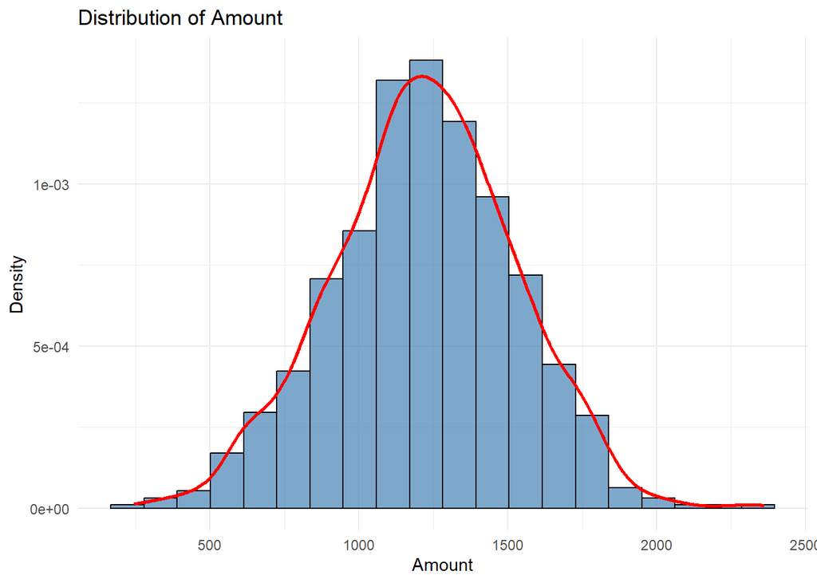

```r
# load CSV bank data
# setwd("C:/Users/Junjie Mei/Desktop/WCU/2025Spring/STA552/Week2")
mpg <- read.csv("https://jm1006958.github.io/STA552/BankLoanDefaultDataset.csv")

#generate  feature  variables
mpg <- mutate(mpg, TotalAmount = Saving_amount + Checking_amount )
mpg <- mutate(mpg, ActualAmount = Saving_amount + Checking_amount - Amount )
mpg <- mutate(mpg, Gender_Marital = paste(Gender, Marital_status, sep = " "))

mpg$Gender_Dummy <- ifelse(mpg$Gender == "Male", 1, 0)
mpg$Marital_status_Dummy <- ifelse(mpg$Marital_status == "Married", 1, 0)
mpg$Emp_status_Dummy <- ifelse(mpg$Emp_status == "employed", 1, 0)
#print(mpg)

# add 150 missing values to 3 numerical variables and 3 categorical variables
#library(tidyverse)
TotalAmount.missing.id <- sample(1:1000, 150, replace = FALSE)
ActualAmount.missing.id <- sample(1:1000, 150, replace = FALSE)
Amount.missing.id <- sample(1:1000, 150, replace = FALSE)
Gender_Marital.missing.id <- sample(1:1000, 150, replace = FALSE)
Gender.missing.id <- sample(1:1000, 150, replace = FALSE)
Marital_status.missing.id <- sample(1:1000, 150, replace = FALSE)
mpg$TotalAmount[TotalAmount.missing.id] <- NA
mpg$ActualAmount[ActualAmount.missing.id] <- NA
mpg$Amount[Amount.missing.id] <- NA
mpg$Gender_Marital[Gender_Marital.missing.id] <- NA
mpg$Gender[Gender.missing.id] <- NA
mpg$Marital_status[Marital_status.missing.id] <- NA

ggplot(mpg, aes(x = Amount)) +
  geom_histogram(aes(y = ..density..), bins = 20, fill = "steelblue", color = "black", alpha = 0.7) +
  geom_density(color = "red", size = 1) +  # Overlay density plot
  ggtitle("Distribution of Amount") +
  xlab("Amount") +
  ylab("Density") +
  theme_minimal()
```

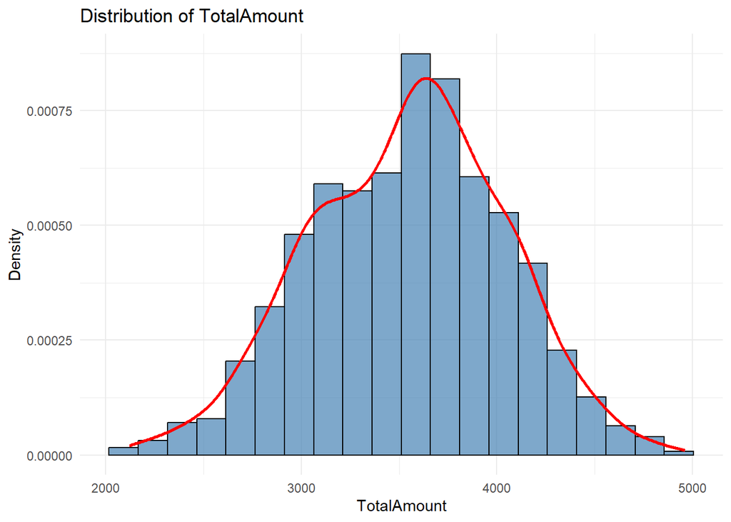

```r
ggplot(mpg, aes(x = TotalAmount)) +
  geom_histogram(aes(y = ..density..), bins = 20, fill = "steelblue", color = "black", alpha = 0.7) +
  geom_density(color = "red", size = 1) +  # Overlay density plot
  ggtitle("Distribution of TotalAmount") +
  xlab("TotalAmount") +
  ylab("Density") +
  theme_minimal()
```

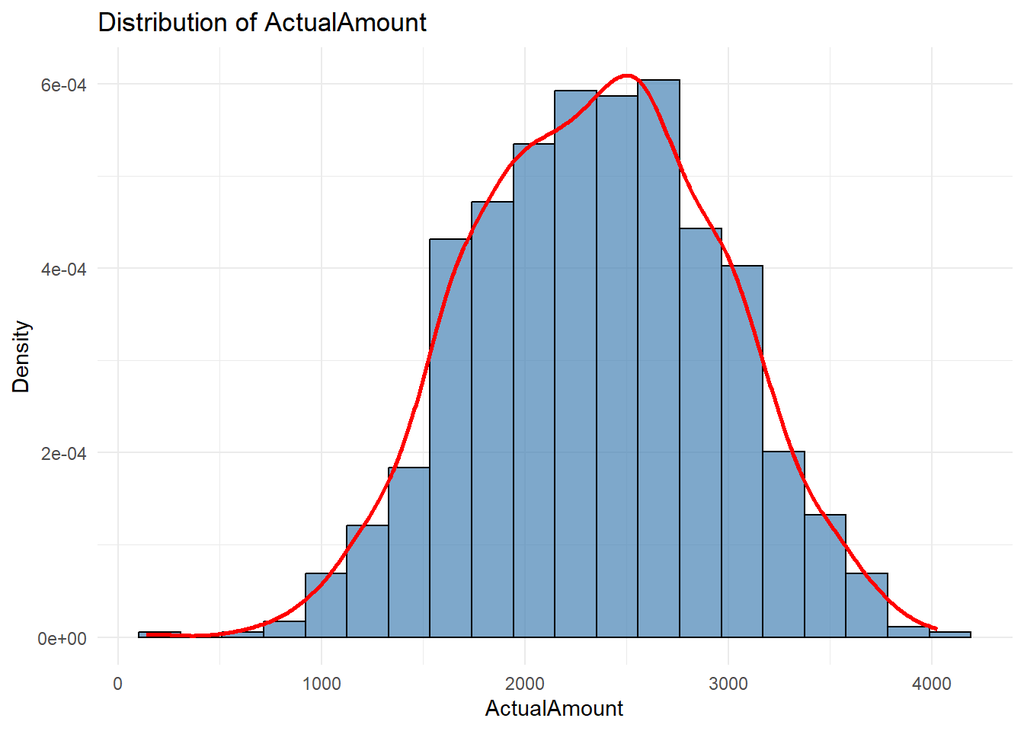

```r
ggplot(mpg, aes(x = ActualAmount)) +
  geom_histogram(aes(y = ..density..), bins = 20, fill = "steelblue", color = "black", alpha = 0.7) +
  geom_density(color = "red", size = 1) +  # Overlay density plot
  ggtitle("Distribution of ActualAmount") +
  xlab("ActualAmount") +
  ylab("Density") +
  theme_minimal()
```

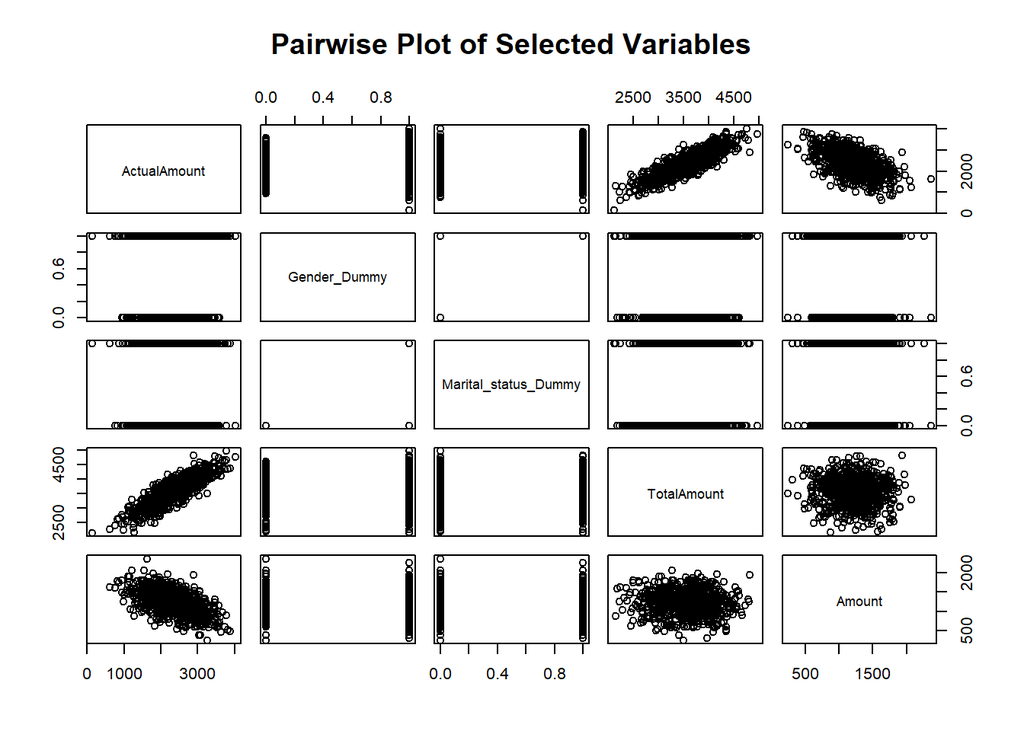

```r
#print(mpg)
pairs(mpg[, c("ActualAmount", "Gender_Dummy", "Marital_status_Dummy", "TotalAmount", "Amount")], main = "Pairwise Plot of Selected Variables")
```

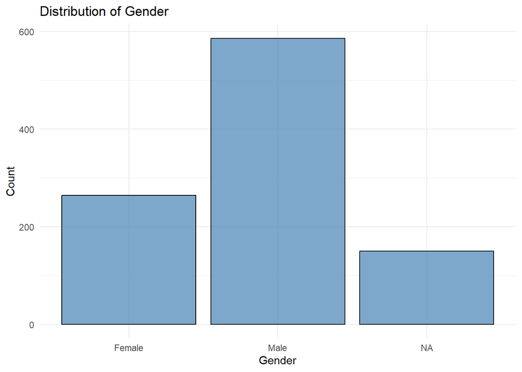

```r
ggplot(mpg, aes(x = Gender)) +
  geom_bar(fill = "steelblue", color = "black", alpha = 0.7) +
  ggtitle("Distribution of Gender") +
  xlab("Gender") +
  ylab("Count") +
  theme_minimal()
```

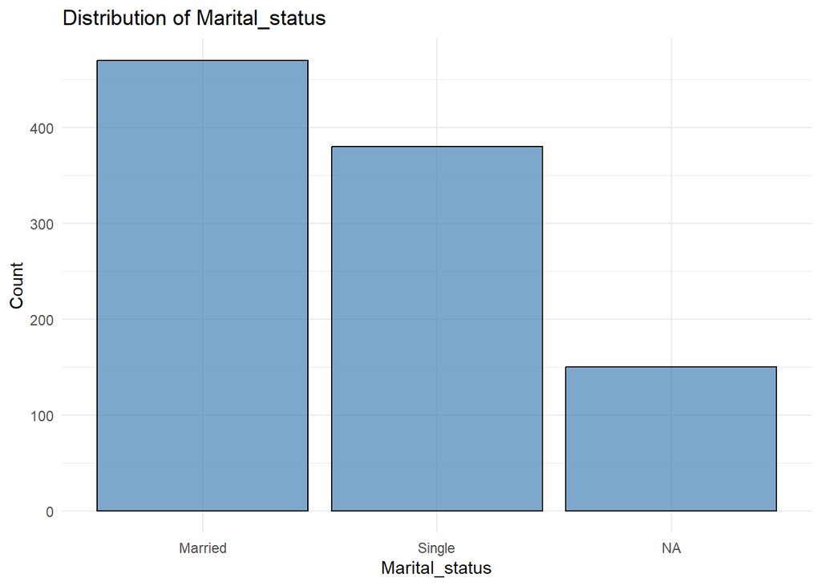

```r
ggplot(mpg, aes(x = Marital_status)) +
  geom_bar(fill = "steelblue", color = "black", alpha = 0.7) +
  ggtitle("Distribution of Marital_status") +
  xlab("Marital_status") +
  ylab("Count") +
  theme_minimal()
```

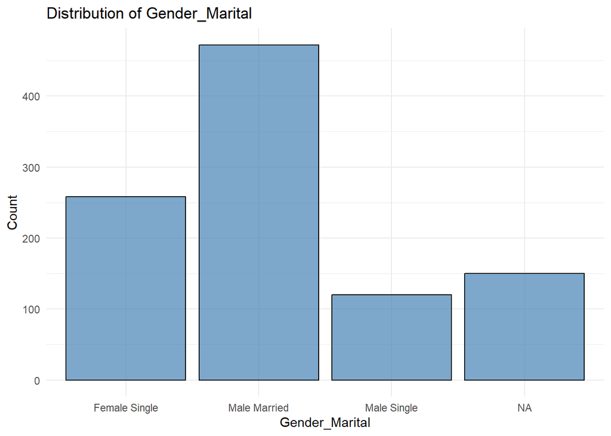

```r
ggplot(mpg, aes(x = Gender_Marital)) +
  geom_bar(fill = "steelblue", color = "black", alpha = 0.7) +
  ggtitle("Distribution of Gender_Marital") +
  xlab("Gender_Marital") +
  ylab("Count") +
  theme_minimal()
```

## 2 Replacement Imputation for Categorical Features

Use the k-nearest neighbors (KNN) algorithm to impute missing values of the “Gender_Marital” variable by assigning the value most common among the k-nearest neighbors surrounding the point with the missing data

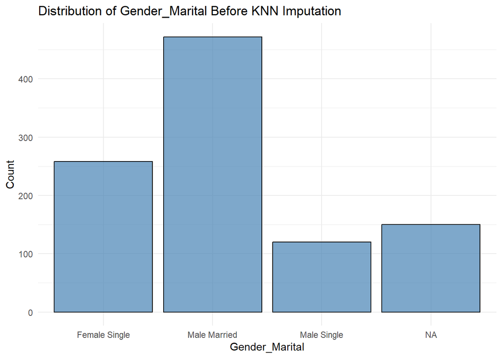

```r
ggplot(mpg, aes(x = Gender_Marital)) +
  geom_bar(fill = "steelblue", color = "black", alpha = 0.7) +
  ggtitle("Distribution of Gender_Marital Before KNN Imputation") +
  xlab("Gender_Marital") +
  ylab("Count") +
  theme_minimal()
```

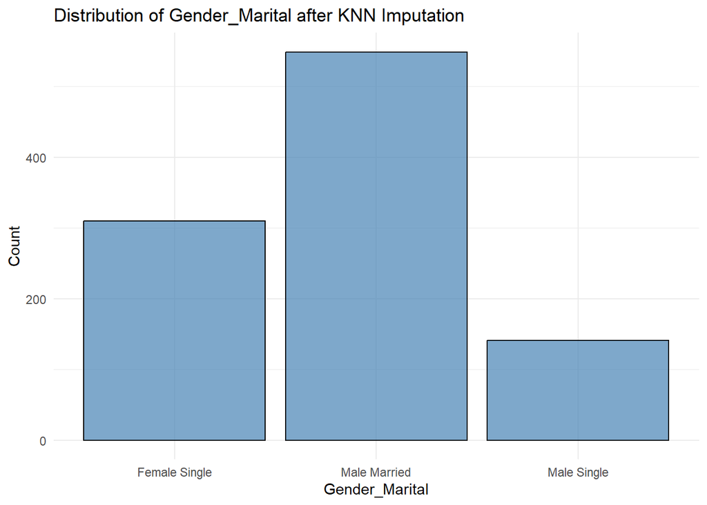

```r
mpg <- kNN(mpg, variable = "Gender_Marital", k = 4)

ggplot(mpg, aes(x = Gender_Marital)) +
  geom_bar(fill = "steelblue", color = "black", alpha = 0.7) +
  ggtitle("Distribution of Gender_Marital after KNN Imputation") +
  xlab("Gender_Marital") +
  ylab("Count") +
  theme_minimal()
```

There is no female married category, indicating in a married family, only husband will work on car loan and personal loan with this bank on this bank-covered area.

## 3 Regression-based Imputation for Numerical Features

Create a subset containing the feature variables associated with the target continuous response variable. Fit a linear regression model using the complete observations from this subset. For instances where the response variable has missing values, predict the missing values using the model’s predicted output, adding random error to account for variability. Note that the feature variables can be a mix of categorical and numerical data types.

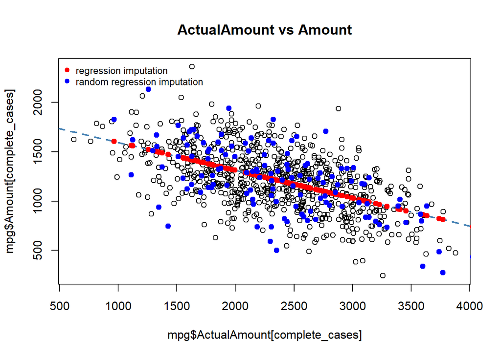

```r
pred.Am = lm(Amount ~ ActualAmount, data = mpg)
newdata = mpg[is.na(mpg$Amount),]
pred.Amount = predict(pred.Am, newdata = newdata)
m0 = sum(is.na(mpg$Amount))
pred.resid = resid(pred.Am)
pred.yrand = pred.Amount + sample(pred.resid, m0, replace = TRUE)

# Ensure no missing values in x-axis data
complete_cases <- !is.na(mpg$ActualAmount) & !is.na(mpg$Amount)
plot(mpg$ActualAmount[complete_cases], mpg$Amount[complete_cases], main = "ActualAmount vs Amount")

abline(pred.Am, col = "steelblue", lty = 2, lwd = 2)

# Plot only for missing values
if (m0 > 0) {
  points(newdata$ActualAmount, pred.Amount, pch=19, col = "red")
  points(newdata$ActualAmount, pred.yrand, pch=19, col = "blue")
}

legend("topleft", c("regression imputation", "random regression imputation"),
       col=c("red", "blue"), pch=rep(19,2), bty="n", cex = 0.8)
```

## 4 Multiple Imputation

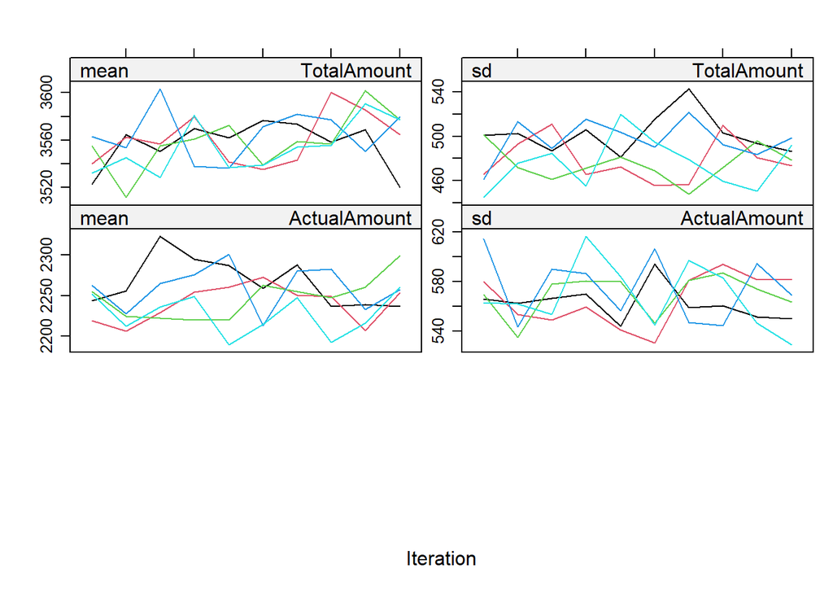

```r
dat <- mpg[,c("TotalAmount","ActualAmount")]  # Example data set with missing values
imp5 <- mice(dat, method = c("pmm","pmm"), m = 5, maxit = 10, seed = 123, print=F)
plot(imp5)
```

```r
model5 <- with(imp5, lm(TotalAmount ~ ActualAmount))  # The statistical model to assess
# the relationship between *Ozone*
# and *Wind* and *Temp*.
summary.stats = summary(model5)               # display the regression results of
# individual imputed data set.
summary.stats
```

```
# A tibble: 10 × 7
   term         estimate std.error statistic   p.value  nobs df.residual
   <chr>           <dbl>     <dbl>     <dbl>     <dbl> <int>       <dbl>
 1 (Intercept)  1901.      33.0         57.5 3.92e-319  1000         998
 2 ActualAmount    0.703    0.0137      51.2 1.39e-281  1000         998
 3 (Intercept)  1903.      31.6         60.1 0          1000         998
 4 ActualAmount    0.705    0.0131      53.7 2.48e-296  1000         998
 5 (Intercept)  1892.      32.1         58.9 0          1000         998
 6 ActualAmount    0.708    0.0133      53.2 1.06e-293  1000         998
 7 (Intercept)  1893.      32.3         58.6 0          1000         998
 8 ActualAmount    0.710    0.0134      52.9 5.52e-292  1000         998
 9 (Intercept)  1870.      32.0         58.5 0          1000         998
10 ActualAmount    0.719    0.0133      54.1 2.65e-299  1000         998
```

```r
summary(pool(model5))
```

```
          term     estimate   std.error statistic        df      p.value
1  (Intercept) 1891.7263317 35.22599398  53.70257 127.99618 1.184774e-89
2 ActualAmount    0.7090974  0.01500409  47.26027  84.74798 1.125925e-62
```

TotalAmount and ActualAmount are positively correlated based on the paired plot above. Due to my problem, I did not have time to finish the 4 tasks for this “Multiple Imputation” question, but I will try my best to complete them later. Thanks!